# Лабораторная работа 5. Основы анализа данных NumPy и Matplotlib.

# Часть 1. NumPy

При решении научных задач с помощью численных методов зачастую приходится иметь дело с большими массивами данных в виде массивов и матриц. Стандартные средства Python (например, использование списков для хранения данных и прямой перебор элементов с помощью циклов) плохо подходят для таких задач, так как будут работать крайне медленно, в отличие от программ на компилируемых языках (Fortran, С). Пакет NumPy (http://www.numpy.org/) — это основной пакет, исполь¬зуемый в научных вычислениях в Python. NumPy предназначен для эф¬фективной работы с многомерными массивами, в том числе для эффек¬тивного применения математических операций к массивам и матрицам и их модификации без прямого перечисления элементов массивов. Поми¬мо этого NumPy обладает и другими возможностями — линейная алгеб¬ра, удобный ввод/вывод в файлы, моделирование случайных величин, быстрое преобразование Фурье, объединение программ на Fortran и С и другое (подробнее см. оф. сайт), поэтому важно изучить возможно¬сти данной библиотеки как можно лучше.

1. Внимательно изучите следующий урок по NumPy: http://scipy.github.io/old-wiki/pages/Tentative_NumPy_Tutorial.
2. Изучите официальное руководство пользователя https://docs.scipy.org/doc/numpy/user/.
3. Внимательно изучите Reference Guide (полное описание всех функ¬ций) https://docs.scipy.org/doc/numpy/reference/, именно в нем перечислены все возможности NumPy, этой ссылкой придется регу¬лярно пользоваться.

Выполните следующие задания (их много, но каждое занимает одну или несколько строк) средствами NumPy (и без использования циклов!)

Импортируйте пакет numpy под именем nр

```python
import numpy as np
```

Импортируйте пакет numpy под именем пр

```python
import numpy as np
```

Создайте вектор из 10 элементов, заполненный 0, пятый эле-мент которого равен 1.

```python
array = np.zeros(10)
array[4]=1
print(array)
```

```
[0. 0. 0. 0. 1. 0. 0. 0. 0. 0.]
```

Создайте вектор из 10 элементов, заполненный 0, пятый эле-мент которого равен 1.

```python
array = np.zeros(10)
array[4]=1
print(array)
```

[output not shown]

Создайте матрицу 3 на 3 со значениями от 0 до 8.

```python
matrix = np.arange(0,9)
matrix = matrix.reshape(3,3)
print(matrix)
```

```
[[0 1 2]
 [3 4 5]
 [6 7 8]]
```

Найдите индексы ненулевых элементов вектора [1,2,0,0,4,0].

```python
array = [1,2,0,0,4,0]
nzero=np.nonzero(array)
print(nzero)
```

```
(array([0, 1, 4], dtype=int64),)
```

Объявите единичную матрицу размером 3 на 3.

```python
onearray=np.eye(3)
print(onearray)
```

```
[[1. 0. 0.]
 [0. 1. 0.]
 [0. 0. 1.]]
```

Создайте массив 10x10x10 из случайных чисел.

```python
randomarray = np.random.random((10,10,10))
print(randomarray)
```

[output not shown]

[output cut: 254 more lines]

[output not shown]

Создайте матрицу 8 на 8, заполненную 0 и 1 в шахматном порядке.

```python
chessarray = np.ones((8,8))
chessarray[::2, 1::2]=0
chessarray[1::2,::2]=0
print(chessarray)
```

```
[[1. 0. 1. 0. 1. 0. 1. 0.]
 [0. 1. 0. 1. 0. 1. 0. 1.]
 [1. 0. 1. 0. 1. 0. 1. 0.]
 [0. 1. 0. 1. 0. 1. 0. 1.]
 [1. 0. 1. 0. 1. 0. 1. 0.]
 [0. 1. 0. 1. 0. 1. 0. 1.]
 [1. 0. 1. 0. 1. 0. 1. 0.]
 [0. 1. 0. 1. 0. 1. 0. 1.]]
```

Найдите произведение матриц 5x3 на 3x2 (см. линейную ал-гебру) .

```python
amatrix = np.arange(15).reshape(5,3)
bmatrix = np.arange(15,21).reshape(3,2)
cmatrix = np.dot(amatrix,bmatrix)
print(cmatrix)
```

```
[[ 55  58]
 [208 220]
 [361 382]
 [514 544]
 [667 706]]
```

Создайте матрицу, в каждом ряду которой стоят числа от 0 до 8 (используйте сложение матрицы с вектором).

```python
wtfmatrix = np.zeros((5,9))
wtfmatrix+=np.arange(0,9)
print(wtfmatrix)
print("\nЗадание с вектором на 1000 елементов:\n")
srsum = np.mean(np.arange(1000))
print(srsum)
```

```
[[0. 1. 2. 3. 4. 5. 6. 7. 8.]
 [0. 1. 2. 3. 4. 5. 6. 7. 8.]
 [0. 1. 2. 3. 4. 5. 6. 7. 8.]
 [0. 1. 2. 3. 4. 5. 6. 7. 8.]
 [0. 1. 2. 3. 4. 5. 6. 7. 8.]]

Задание с вектором на 1000 елементов:

499.5
```

Создайте вектор длины 1000. Найдите среднее (арифметиче¬ское) значение из этих элементов.

## Часть 2. Matplotlib

Matplotlib (http://matplotlib.org/index.html) — это библиотека для создания графиков в Python. Matplotlib позволяет строить графики любой сложности типографского качества, которые можно вставить в статью. Подробнее о возможностях см. http://matplotlib.org/users/ intro.html. Matplotlib — большой и сложный инструмент, но на прак¬тике в научных вычислениях часто пользуются частью библиотеки matplotlib .pyplot, которая имитирует построение графиков в стиле MATLAB. В качестве до¬статочно полного введения можно прочитать http://matplotlib.org/users/index.html.

На практике бывает очень трудно помнить все возможности Matplotlib, поэтому часто используют галереи готовых примеров, а потом модифи-цируют их под свои нужды. Примеры таких подборок можно найти по следующим ссылкам: • http://matplotlib.org/gallery.html • http://matplotlib.org/examples/index.html • http://wiki.scipy.org/Cookbook/Matplotlib/

Еще материалы.

1. Введение http://matplotlib.org/users/pyplot_tutorial.html
2. Введение 2 http://www.loria.fr/~rougier/teaching/matplotlib/. Изучите, как создавать графики разных типов http://www.loria. fr/~rougier/teaching/matplotlib/#other-types-of-plots.
3. Использование текста в подписях и т.д. http://matplotlib.org/ users/text_intro.html.
4. Использование математического текста http: //matplotlib. org/users/ mathtext.html.
5. Создание легенды http://matplotlib.org/users/legend_guide.html.
6. Интерактивное использование Matplotlib http: //matplotlib. org/ users/shell .html (этот пример можно использовать не только в командной строке, но и в коде для наблюдения за изменением гра¬фиков в ходе выполнения программы).

Постройте поточечный график функции. Сгенерируйте два массива для этого. Один со значениями по возрастанию (для X), второй со случайными значениями (для Y).

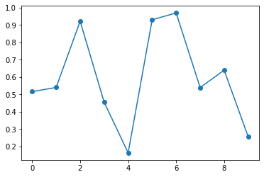

```python
import matplotlib.pyplot as plt
plt.plot(np.arange(10),np.random.random(10), '-o')
```

Выберите тригонометрическую функцию $T(x)$, выберите полином $P(x)$. Постройте график функции $T(x)P(x)$.

[figure not shown]

```python
T = np.sin(x)
P = x**3+2*x**2+4*x+5
TP = T*P
plt.plot(x, TP)
```

К графику добавьте: обозначение оси абсцисс, обозначение оси ординат, название графика, вставка легенды (текста в label).

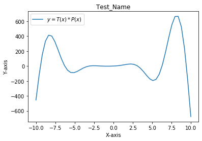

```python
T = np.sin(x)
P = x**3+2*x**2+4*x+5
TP = T*P
fig, ax = plt.subplots()
ax.plot(x, TP, label = '$y = T(x)*P(x)$')
ax.legend(loc='best')
ax.set_xlabel('X-axis')
ax.set_ylabel('Y-axis')
plt.title('Test_Name')
```

Измените цвет графика на Ваш любимый.

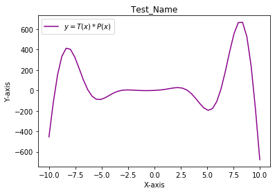

```python
T = np.sin(x)
P = x**3+2*x**2+4*x+5
TP = T*P
fig, ax = plt.subplots()
ax.plot(x, TP, label = '$y = T(x)*P(x)$', color = 'darkmagenta')
ax.legend(loc='best')
ax.set_xlabel('X-axis')
ax.set_ylabel('Y-axis')
plt.title('Test_Name')
```

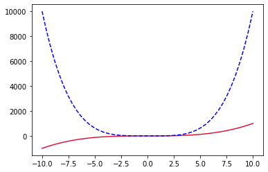

```python
x = np.linspace(-10,10,50)
plt.plot(x,x**3, color = 'crimson', linestyle = 'solid')
plt.plot(x,x**4, color = 'blue', linestyle = 'dashed')
```

Постройте теже графики, только для первого добавьте маркеры из красных треугольников, для второго синие круглые маркеры.

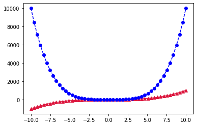

```python
x = np.linspace(-10,10,50)
y = x**3
z = x**4
fig, ax= plt.subplots()
ax.plot(x,y, color = 'crimson', linestyle = 'solid', marker = '^')
ax.plot(x,z, color = 'blue', linestyle = 'dashed', marker = 'o')
plt.show()
fig.savefig('TEst')
```

Запрограмируйте сохранение графика.

# Часть 3. OpenCV

Прочитайте картинку используя opencv

```python
import cv2
img = cv2.imread('D:\Angel.jpg')
#window_name = 'image'
#cv2.imshow(window_name, image)
#cv2.waitKey(0)
#cv2.destroyAllWindows()
#Закомменченные строки для вывода изображения, но у меня почему то не работает
```

Сделайте ее черно-белой

```python
img = cv2.imread('D:\Angel.jpg')
ret, thres = cv2.threshold(img, 127, 255, 0)
cv2.imwrite('D:\Angel2.jpg', thres) #Функция сохранения на диск, написал для проверки
```

```
True
```

Измените размер на 300x300

```python
img = cv2.imread('D:\Angel.jpg')
dim = (300, 300)
resized = cv2.resize(img, dim, interpolation = cv2.INTER_AREA)
cv2.imwrite('D:\Angel3.jpg', resized)
```

```
True
```

Разбейте ее на 2 картинки. Сохраните.

```python
#Это очень кривой метод, но по другому я не придумал и функций не нашел
img = cv2.imread('D:\Angel.jpg')
width = int(img.shape[1] * 0.5)
height = int(img.shape[0])
cropped1 = img[0:height, 0:width]
cropped2 = img[0:height,width:width*2]
cv2.imwrite('D:\Angelc1.jpg', cropped1)
cv2.imwrite('D:\Angelc2.jpg', cropped2)
```

```
True
```

Прочитайте 2 картинки и склейте.

```python
import numpy as np
img1 = cv2.imread('D:\Angelc1.jpg')
img2 = cv2.imread('D:\Angelc2.jpg')
vis = np.concatenate((img1, img2), axis=1)
cv2.imwrite('D:\AngelVIS.jpg', vis)
```

```
True
```